# RFM Sample

Don Lim

6/4/2022

# Preliminary work

## Libraries

```r
library(readxl)
library(dplyr)
library(pastecs)
library(ggplot2)
library(lubridate)
library(rfm)
library(cluster)
library(factoextra)
library(CLVTools)
library(caret)
```

## Import data

Reads data and removes any missing values that might be present.

```r
url <- "https://archive.ics.uci.edu/ml/machine-learning-databases/00502/online_retail_II.xlsx"
destfile <- "online_retail_II.xlsx"
curl::curl_download(url, destfile)
df <- read_excel(destfile)
df <- na.omit(df)
```

I will create the following columns for analysis:

1. InvoiceDateDay, which will be the same as the InvoiceDate column but without the time
2. Revenue, which will be the quantity times price

and

3. Filter out negative reveneue (so filtering either negative quantity or prices)

```r
df$InvoiceDateDay <- as_date(df$InvoiceDate)
df$Revenue <- as.numeric(df$Quantity * df$Price)

df <- df %>%
    filter(Revenue > "0")
```

# Initial plots

## Purchase frequency (pf) by customer

```r
pf <- df %>%
    group_by(`Customer ID`) %>%
    summarise(count = n_distinct(Invoice))
```

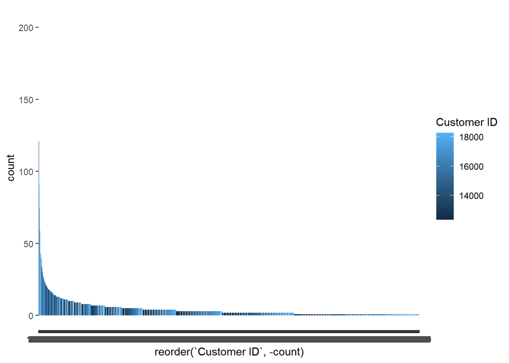

```r
pf_bp <- ggplot(data = pf, aes(x = reorder(`Customer ID`, -count), y = count, fill = `Customer ID`)) +
    geom_bar(stat = "identity")

pf_bp
```

```r
pf <- pf[order(pf$count, decreasing = T), ]

head(pf)
```

| Customer ID | count |
| --- | --- |
| 14911 | 205 |
| 17850 | 155 |
| 12748 | 144 |
| 15311 | 121 |
| 13089 | 109 |
| 14156 | 102 |

As we can see, the distribution of purchases from customers follow a fairly wide distribution, with the customer #14911 purchasing the most number of orders. However, simply because the customer may purchase the most orders may not necessarily mean they spend the most money.

## Total money spent (tms)

```r
tms <- df %>%
    group_by(`Customer ID`) %>%
    summarise(total = sum(Revenue))
```

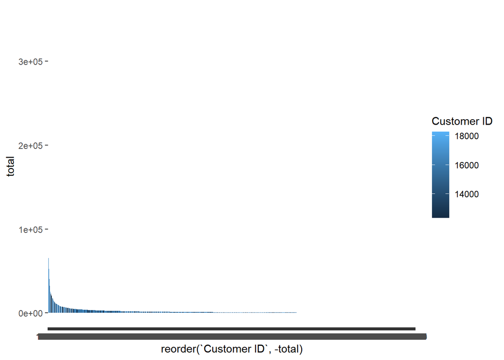

```r
tms_bp <- ggplot(data = tms, aes(x = reorder(`Customer ID`, -total), y = total, fill = `Customer ID`)) +
    geom_bar(stat = "identity")

tms_bp
```

```r
tms <- tms[order(tms$total, decreasing = T), ]

head(tms)
```

| Customer ID | total |
| --- | --- |
| 18102 | 349164.35 |
| 14646 | 248396.50 |
| 14156 | 196566.74 |
| 14911 | 152147.57 |
| 13694 | 131443.19 |
| 17511 | 84541.17 |

# RFM analysis

```r
analysis_date <- as_date("2010-12-09")

rfm_result <- rfm_table_order(df, `Customer ID`, InvoiceDateDay, Revenue, analysis_date)

rfm_result
```

[output not shown]

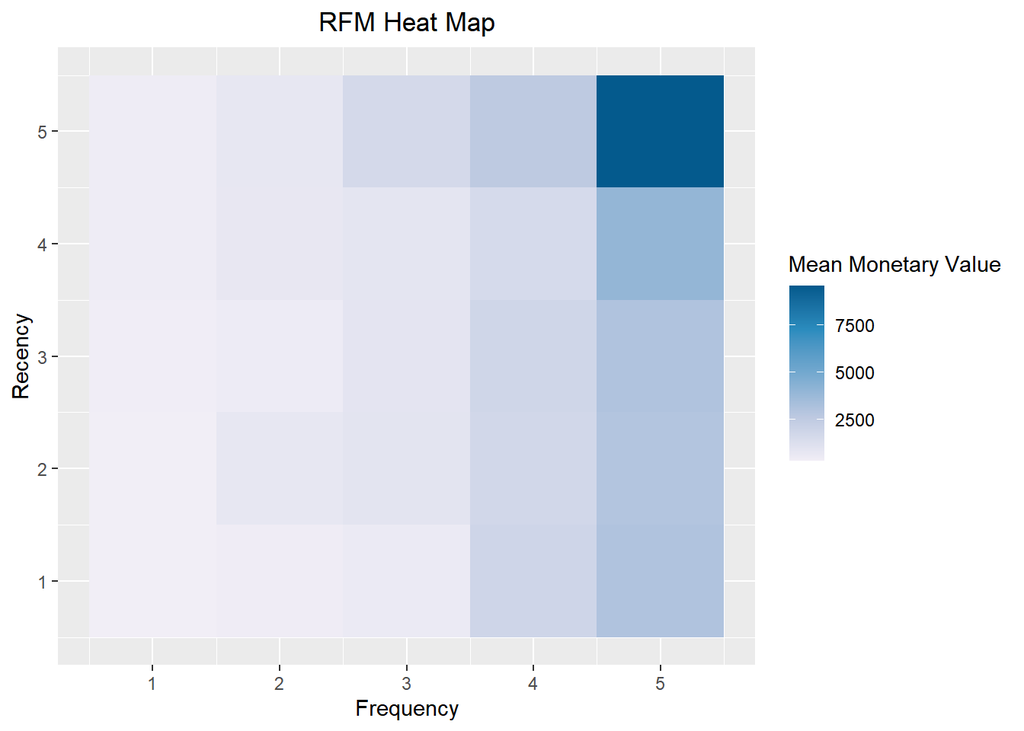

```r
rfm_heatmap(rfm_result)
```

We can notice here that a large amount of monetary value is concentrated in high-frequency-purchasing consumers.

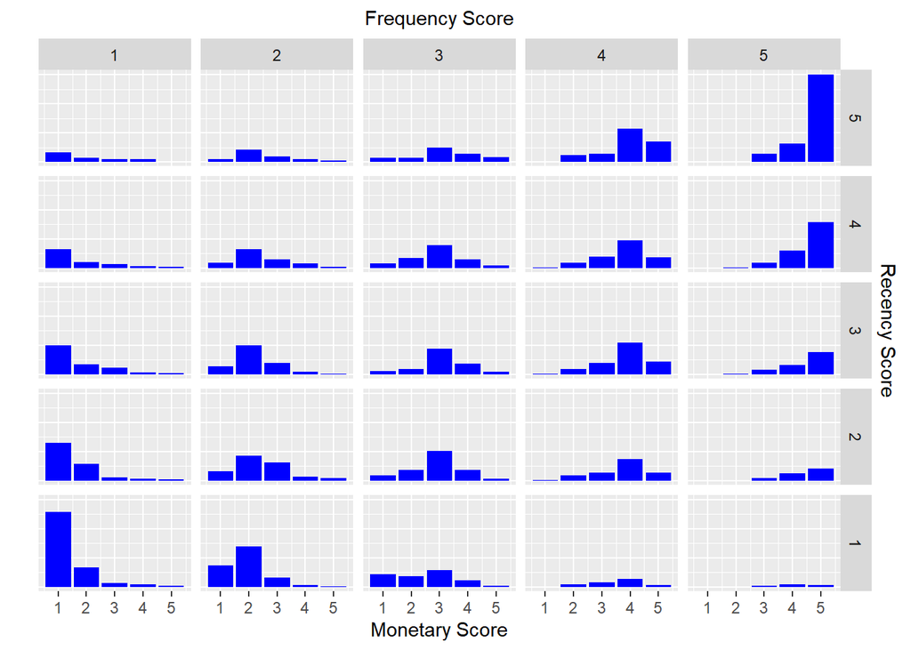

```r
rfm_bar_chart(rfm_result)
```

Many of the consumers shop frequently, but there are quite a few consumers who have not shopped recently. We should delve deeper to see what types of products these consumers bought and if any promotions, coupons, and advertisements would entice them to revisit the store.

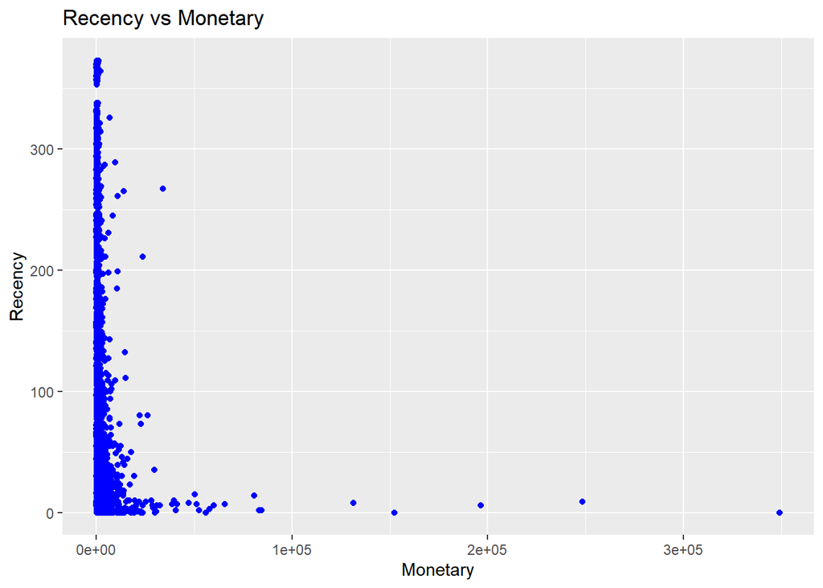

```r
rfm_rm_plot(rfm_result)
```

It seems like a majority of consumers have shopped within the last 100 days. However, there are a few medium spenders who have have not purchased anything near the last 200 and 300 days.

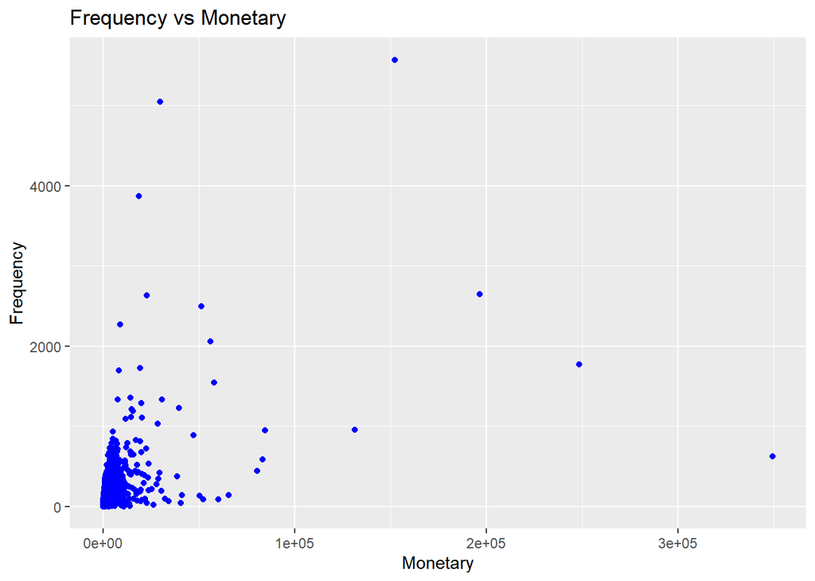

```r
rfm_fm_plot(rfm_result)
```

Unsurprisingly, there is a positive correlation between frequency of purchases and monetary value.

# Segmentation

```r
segment_names <- c("Champions", "Loyal Customers", "Potential Loyalist", "New Customers",
    "Promising", "Need Attention", "About To Sleep", "At Risk", "Can't Lose Them",
    "Lost")

recency_lower <- c(4, 2, 3, 4, 3, 2, 2, 1, 1, 1)
recency_upper <- c(5, 5, 5, 5, 4, 3, 3, 2, 1, 2)
frequency_lower <- c(4, 3, 1, 1, 1, 2, 1, 2, 4, 1)
frequency_upper <- c(5, 5, 3, 1, 1, 3, 2, 5, 5, 2)
monetary_lower <- c(4, 3, 1, 1, 1, 2, 1, 2, 4, 1)
monetary_upper <- c(5, 5, 3, 1, 1, 3, 2, 5, 5, 2)

segment <- rfm_segment(rfm_result, segment_names, recency_lower, recency_upper, frequency_lower,
    frequency_upper, monetary_lower, monetary_upper)
```

```r
segment %>%
    group_by(segment) %>%
    summarise(count = n_distinct(customer_id))
```

| segment | count |
| --- | --- |
| About To Sleep | 220 |
| At Risk | 423 |
| Champions | 900 |
| Lost | 401 |
| Loyal Customers | 1138 |
| Need Attention | 186 |
| Others | 267 |
| Potential Loyalist | 777 |

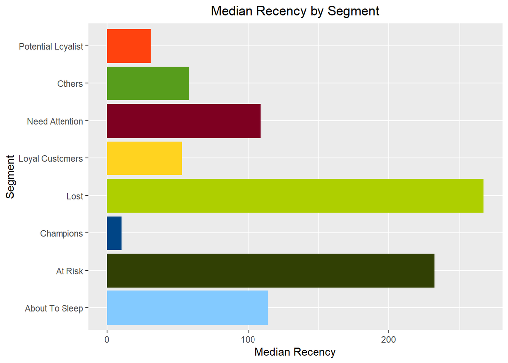

```r
rfm_plot_median_recency(segment)
```

```r
product <- df %>%
    group_by(Description) %>%
    summarise(count = n_distinct(Invoice))

product <- product[order(product$count, decreasing = T), ]
```

# Clustering

```r
cdf_columns <- c("recency_score", "frequency_score", "monetary_score")

cdf <- segment %>%
    select(all_of(cdf_columns))

cdf <- scale(cdf)
```

## Elbow nethod

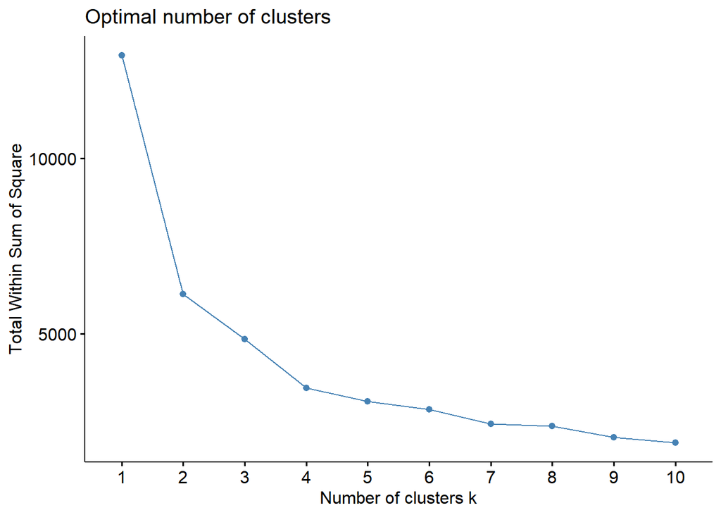

```r
set.seed(123)
fviz_nbclust(cdf, kmeans, method = "wss")
```

For the elbow method, it seems that the recommendation is 4 clusters.

## Silhouette method

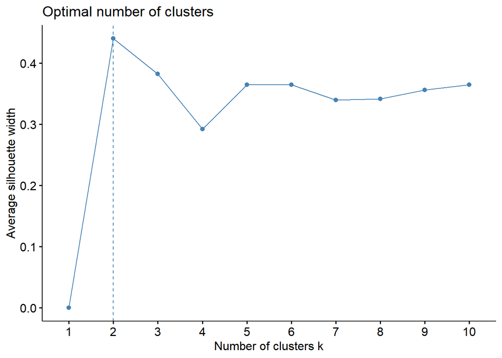

```r
set.seed(123)
fviz_nbclust(cdf, kmeans, method = "silhouette")
```

This method shows that 2 clusters maximize the average silhouette values. 3 clusters coming in second and 6 clusters coming in third as the next optimal values.

## Gap statistic method

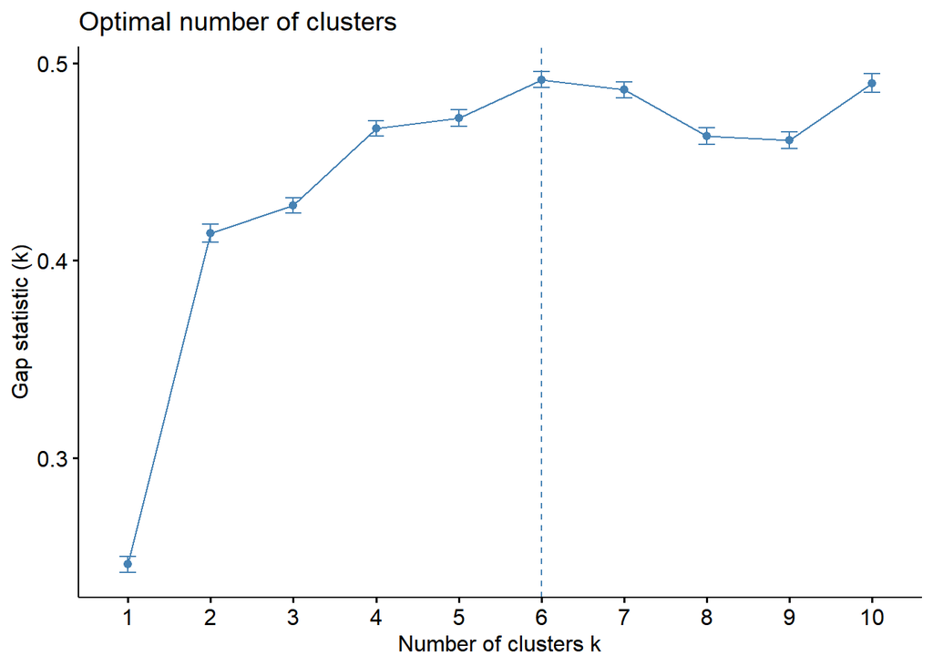

```r
gap_stat <- clusGap(cdf, FUN = kmeans, nstart = 25, K.max = 10, B = 50)

fviz_gap_stat(gap_stat)
```

The gap statistic has been published by R. Tibshirani, G. Walther, and T. Hastie (Standford University, 2001). For this method, the optimal amount of clusters is 6. For this sample, we will use this method and the 6 clusters that recommends.

```r
set.seed(123)

final_cluster <- kmeans(cdf, 6, nstart = 25)
print(final_cluster)
```

```
## K-means clustering with 6 clusters of sizes 551, 730, 620, 973, 935, 503
##
## Cluster means:
##   recency_score frequency_score monetary_score
## 1    -1.0114978    -0.082082173     0.09271237
## 2     0.6097657     0.008418914     0.04617592
## 3     0.4877222    -0.990474486    -0.99241265
## 4     1.1134929     1.151350302     1.10430293
## 5    -1.1680195    -1.040511389    -1.10804316
## 6    -0.3608584     1.005546631     0.97820379
##
## Clustering vector:
##    [1] 1 4 5 6 3 3 3 5 4 4 4 6 4 5 5 5 1 6 1 6 1 6 3 4 1 2 6 4 3 3 1 2 6 5 2 4 1
##   [38] 2 3 2 5 5 4 2 6 5 3 6 3 5 4 5 6 6 3 3 4 2 6 1 1 3 4 4 4 3 4 4 1 1 3 5 3 3
##   [75] 3 6 2 6 2 2 5 5 5 3 6 6 5 4 4 4 3 4 4 4 4 6 4 6 1 2 5 4 3 2 5 5 4 5 6 1 3
```

[output cut: 123 more lines]

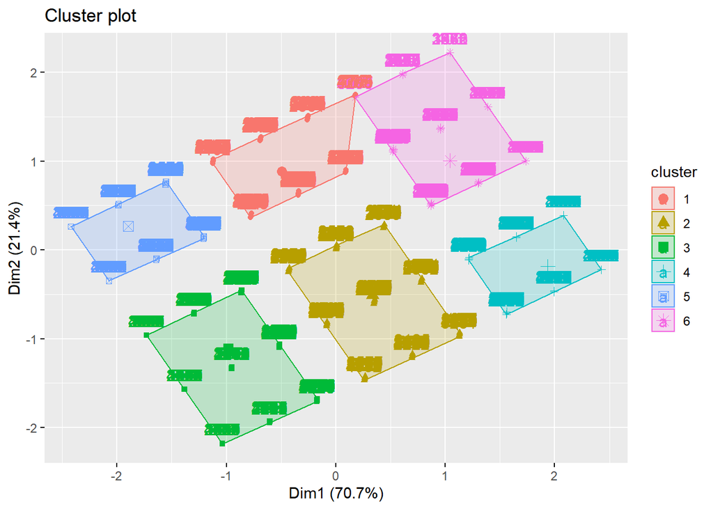

```r
fviz_cluster(final_cluster, data = cdf)
```

Now that we have our 6 clusters, we should extract these clusters into our initial data and provide the means of these clusters.

```r
cluster <- final_cluster$cluster

consumer_cluster <- cbind(segment, cluster) %>%
    group_by(cluster) %>%
    summarise_all("mean")

print(consumer_cluster)
```

```
## # A tibble: 6 x 10
##   cluster customer_id segment rfm_score transaction_count recency_days amount
##     <int>       <dbl>   <dbl>     <dbl>             <dbl>        <dbl>  <dbl>
## 1       1      15275.      NA      190.              45.4        166.   1043.
## 2       2      15488.      NA      422.              51.1         30.3   910.
## 3       3      15350.      NA      389.              17.1         34.2   291.
## 4       4      15319.      NA      512.             253.          12.9  5917.
## 5       5      15432.      NA      152.              15.2        214.    241.
## 6       6      15135.      NA      300.             147.          81.7  2844.
## # ... with 3 more variables: recency_score <dbl>, frequency_score <dbl>,
## #   monetary_score <dbl>
```

From these means, we can categorize our 6 clusters.

# Lifetime value

```r
clv_df <- clvdata(df, date.format = "ymd", time.unit = "day", name.id = "Customer ID",
    name.date = "InvoiceDateDay", name.price = "Revenue")

summary(clv_df)
```

```
## CLV Transaction Data
##
## Time unit         Days
## Estimation length 373.0000 Days
## Holdout length    -
##
## Transaction Data Summary
##                                    Estimation       Holdout      Total
## Number of customers                -                -            4312
## First Transaction in period        2009-12-01       -            2009-12-01
## Last Transaction in period         2010-12-09       -            2010-12-09
## Total # Transactions               16999            -            16999
## Mean # Transactions per cust       3.942            -            3.942
## (SD)                               6.020            -            6.020
## Mean Spending per Transaction      519.560          -            519.560
## (SD)                               1121.623         -            1121.623
## Total Spending                     8832003.274      -            8832003.274
## Total # zero repeaters             1494             -            -
## Percentage of zero repeaters       34.647           -            -
## Mean Interpurchase time            77.368           -            77.368
## (SD)                               63.105           -            63.105
```

```r
est_clv <- gg(clv_df)
predict(est_clv)
```

| Id | predicted.mean.spending |
| --- | --- |
| 12346 | 109.17668 |
| 12347 | 554.57642 |
| 12348 | 422.31144 |
| 12349 | 660.03049 |
| 12351 | 422.31144 |
| 12352 | 320.75848 |
| 12353 | 422.31144 |
| 12355 | 422.31144 |
| 12356 | 989.07191 |
| 12357 | 422.31144 |

[output cut: 4302 more lines]

Here we have the predicted value of each customer’s spending. We can further analyze or even cluster these results. Another method that would approximate CLV is calculating the average revenue per using (ARPU).

# Retention

Let’s filter out all the data that is after January 1st, 2010 to focus on the customers within the year 2009-2010.

```r
df09 <- df %>%
    filter(df$InvoiceDateDay < "2010-01-01")
```

## Method 1

In order to predict which customers from this period will be most likely to be repeat customers in 2010-2011, we could conduct an RFM analysis in order to see which customers are the most frequent shoppers.

```r
analysis_date2 <- as_date("2009-12-31")

rfm_result2 <- rfm_table_order(df09, `Customer ID`, InvoiceDateDay, Revenue, analysis_date2)

rfm_result2
```

[output not shown]

```r
segment2 <- rfm_segment(rfm_result2, segment_names, recency_lower, recency_upper,
    frequency_lower, frequency_upper, monetary_lower, monetary_upper)
```

```r
shopper_cols = c("customer_id", "segment")

frequent_shoppers <- segment2 %>%
    select(all_of(shopper_cols)) %>%
    filter(segment == "Champions" | segment == "Loyal Customers")

frequent_shoppers
```

| customer_id | segment |
| --- | --- |
| 12358 | Loyal Customers |
| 12359 | Champions |
| 12417 | Loyal Customers |
| 12439 | Champions |
| 12440 | Loyal Customers |
| 12443 | Loyal Customers |
| 12455 | Champions |
| 12471 | Champions |
| 12472 | Champions |
| 12510 | Loyal Customers |

[output cut: 359 more lines]

Here is the list of 2009-2010 customers that we would expect to be repeat customers in 2010-2011. We could also add the list of customers who we labelled as “Potential Loyalists.”

## Method 2

In order to predict future purchases, we could model the probability of buying a product based on the RFM scores of each unique customer. One method would be using a logit model, where we could create a cutoff at probabilities above or below 0.5 for customers that WILL BUY and customers that WILL NOT BUY in the future.

Another technique for this method could be to use machine learning. I could split the data into a 70% to create the model and 30% to verify the accuracy.

If I created a dummy variable where 1 represented bought and 0 represented not bought, the following code would look something like this

> inTrain = createDataPartition(y = segment2$transaction_count, p = 0.7, list = F) trainingSet = segment2[inTrain,] testSet = segment2[-inTrain,]

> mod = train( transaction_count ~ ., data = trainingSet, method = “glm”, family = “binomial”

To get the predictions, I would run the following:

> ptest = predict(mod, newdata = testSet) ptrain = predict(mod, newdata = trainingSet)

And to get the accuracy:

> mean(ptrain == trainingSet$y) mean(ptest == TestSet$y)

# 10 percent discounted future sales

In order to determine if the 10 percent discount on sales will result in greater or lower total revenue, we would need to predict the following:

1. Customers moving from potentially loyal to loyal customers
2. Loyal customers moving to champion customers
3. Influx of new customers

If the monetary value from this offsets the 10 percent discount on sales, then the company could potentially see greater revenue. This is, of course, assuming other factors remain the same, such as other competing firms do not change their prices, too.

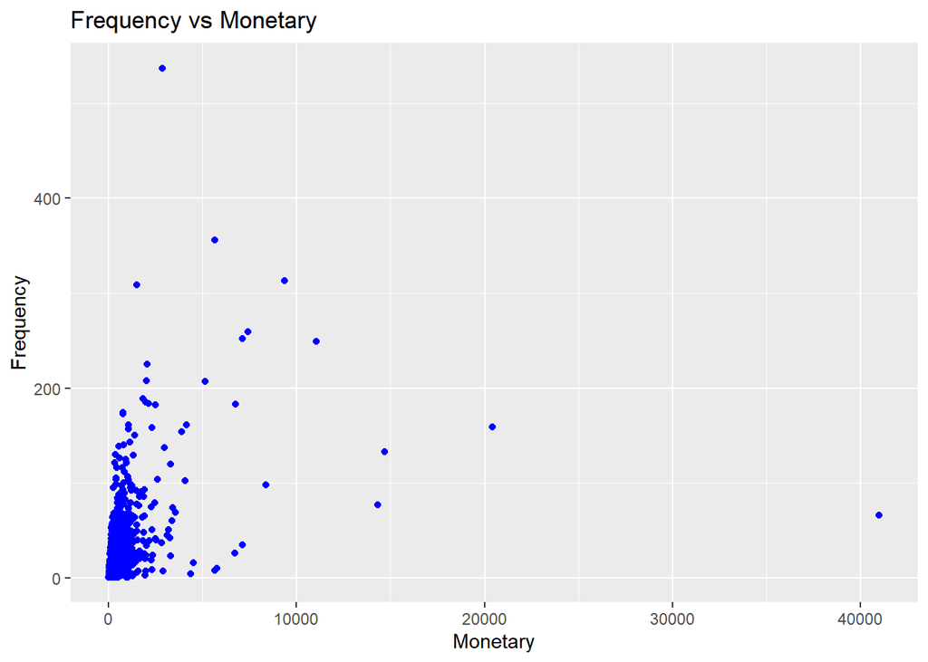

```r
rfm_fm_plot(rfm_result2)
```

```r
est_rfm = lm(transaction_count ~ frequency_score + monetary_score + amount, data = segment2)

summary(est_rfm)
```

```
##
## Call:
## lm(formula = transaction_count ~ frequency_score + monetary_score +
##     amount, data = segment2)
##
## Residuals:
##     Min      1Q  Median      3Q     Max
## -189.25  -12.34   -3.26    7.23  456.72
##
## Coefficients:
##                   Estimate Std. Error t value Pr(>|t|)
## (Intercept)     -26.598059   2.530994 -10.509  < 2e-16 ***
## frequency_score  17.141026   0.798433  21.468  < 2e-16 ***
## monetary_score    1.626595   0.836508   1.945   0.0521 .
## amount            0.004585   0.000556   8.247 5.38e-16 ***
## ---
## Signif. codes:  0 '***' 0.001 '**' 0.01 '*' 0.05 '.' 0.1 ' ' 1
##
## Residual standard error: 29.7 on 951 degrees of freedom
## Multiple R-squared:  0.4917, Adjusted R-squared:  0.4901
## F-statistic: 306.7 on 3 and 951 DF,  p-value: < 2.2e-16
```

This is just the initial model but I could create and incorporate dummy variables for the country of the consumer and see if the adjusted R squared results in a better explanation of the phenomenon.

# References

Academy, R. (2019). RFM Analysis in R — R-bloggers. Retrieved 2022, from https://www.r-bloggers.com/2019/02/rfm-analysis-in-r/

Chen, D., Guo, K., & Ubakanma, G. (2015). Predicting customer profitability over time based on RFM time series. International Journal of Business Forecasting and Marketing Intelligence, 2(1), 1.

Chen, D., Sain, S. L., & Guo, K. (2012). Data mining for the online retail industry: A case study of RFM model-based customer segmentation using data mining. Journal of Database Marketing & Customer Strategy Management, 19(3), 197–208.

G, D. (N.d.). RFM Customer Segmentation with K Means. RPubs. Retrieved 2022, from https://rpubs.com/DessiG/671942

Zaldivar, E. (2020). Tutorial: RFM Analysis Using R. RPubs. Retrieved 2022, from https://rpubs.com/Eddie_Zaldivar/705462